# GroupProject

Sehaj Raina, Hayley Brackenridge, Minji Kweon, Vivian Li

April 22, 2019

# INTRO:

We will be looking at the following datset from this link: (http://bowtie-bio.sourceforge.net/recount/?fbclid=IwAR18Rd0buwg7OMb0XP7VuxBKXfQtWIOHHlIBRPK-ZrrkbyR_fjPrzN1sekw) containing *C. elegans* DNA from different developmental stages. With this data we will address the following questions:

**1. What genes are differentially expressed at different developmental stages in *C. elegans***

**2. Based on the most differentiated gene across the developmental stages, is there homology in that gene amongst different species *Note: this will require NCBI BLAST search and the construction of a phylogentic tree***

# PART 1:Transcriptome Analysis

## 1. Load packages

```r
suppressMessages(library(BiocManager))
install("IRanges")
```

```
## Bioconductor version 3.8 (BiocManager 1.30.4), R 3.5.2 (2018-12-20)
```

```
## Installing package(s) 'IRanges'
```

```
##
##  /var/folders/b_/qqqf4p8j4jsbrdl6hw38b_cc0000gn/T//Rtmpzkrt5H/downloaded_packages
```

[output not shown]

```r
BiocManager::install("DESeq2")
```

```r
BiocManager::install("pheatmap")
suppressMessages(library(DESeq2))
suppressMessages(library(dplyr))
suppressMessages(library(pheatmap))
suppressMessages(library(ggplot2))
```

## 2.a) Analysis - ALL STAGES

```r
load("data/modencodeworm_eset.RData")

expr_se<-SummarizedExperiment(exprs(modencodeworm.eset))
colData(expr_se)<-DataFrame(pData(modencodeworm.eset))

expr_de<- DESeqDataSet(expr_se, design= ~ ERA.library.id)
```

```
## renaming the first element in assays to 'counts'
```

```
##   Note: levels of factors in the design contain characters other than
##   letters, numbers, '_' and '.'. It is recommended (but not required) to use
##   only letters, numbers, and delimiters '_' or '.', as these are safe characters
##   for column names in R. [This is a message, not an warning or error]
```

```r
de_results<- DESeq(expr_de)
```

```
##   Note: levels of factors in the design contain characters other than
##   letters, numbers, '_' and '.'. It is recommended (but not required) to use
##   only letters, numbers, and delimiters '_' or '.', as these are safe characters
##   for column names in R. [This is a message, not an warning or error]
```

[output not shown]

[output not shown]

```r
DEdat<-results(de_results)
```

## 2.b) Visualization - ALL STAGES

```r
vsd<-vst(de_results, blind=F)
ntd<-normTransform(de_results)

Top20<-order(rowMeans
             (counts(de_results, normalized=TRUE)),
             decreasing=TRUE) [1:20]

DEdat[Top20,]
```

```
## log2 fold change (MLE): ERA.library.id YA ce0122 rw004 vs AdultSPE9 ce1004 rw1001
## Wald test p-value: ERA.library.id YA ce0122 rw004 vs AdultSPE9 ce1004 rw1001
## DataFrame with 20 rows and 6 columns
##                    baseMean     log2FoldChange             lfcSE
##                   <numeric>          <numeric>         <numeric>
## F31E3.5    116208.724857872 -0.786777454684986 0.482233761289081
## F25H5.4    106667.968950077 -0.680578529229906 0.433755308242652
## C26F1.9    98154.7640072918  -2.22184390357791  0.87800107026246
## B0513.3    89133.2017212104  -1.75830504672543  0.99283045266015
## Y39B6A.20  77904.0516430382  -1.90290817579626 0.625306802240809
## ...                     ...                ...               ...
## B0393.1    63435.3797241611 -0.320986372554297  0.33688410989506
## Y43B11AR.4 61942.7372296935 -0.958692942871487 0.272279859258165
## K11H12.2   61482.5533570799  -1.07649716527509 0.456976078054241
## B0041.4     58759.985294411 -0.611545736202475 0.423432261994063
## C47E8.5    56653.9686433603 -0.429342094357256 0.394234778666657
##                          stat               pvalue                padj
##                     <numeric>            <numeric>           <numeric>
## F31E3.5     -1.63152710955329    0.102779144382729   0.221637536796584
## F25H5.4      -1.5690379259847    0.116639102127123   0.243053260388061
## C26F1.9     -2.53057083736098   0.0113877087656441  0.0398733782254519
## B0513.3     -1.77100233178212   0.0765603139681591   0.178090033861584
## Y39B6A.20   -3.04315924435353  0.00234108411203831  0.0111022645376485
## ...                       ...                  ...                 ...
## B0393.1    -0.952809476986863      0.3406866117151   0.521162507146094
## Y43B11AR.4  -3.52098368745847 0.000429949065318744 0.00272725266873433
## K11H12.2    -2.35569697621526   0.0184879922621197  0.0587428919264292
## B0041.4     -1.44425871879136    0.148666213214612   0.290537574975514
## C47E8.5     -1.08905179753378     0.27613104456316   0.451244649984206
```

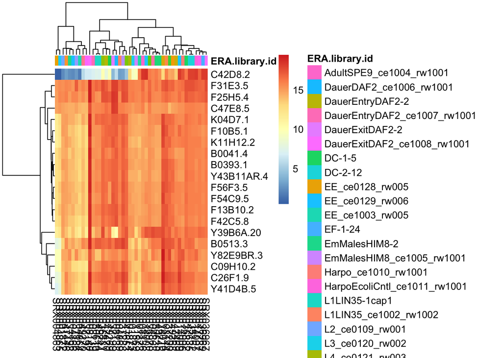

```r
annot_df<-data.frame(ERA.library.id=colData(expr_se)$ERA.library.id,
                     row.names=row.names(colData(expr_se)))

pheatmap(assay(ntd) [Top20,], annotation_col = annot_df) #heat map
```

[figure not shown]

```r
plotPCA(vsd, intgroup="ERA.library.id") + theme_bw() #PCA plot
```

#### *Figure 1.* **All Stages Heat Map** and *Figure 2.* **All Stages PCA Plot**

The Figure 1 heat map shows us regions of higher and lower gene expression, specifically the vitellogenin-2 (vit-2) protein gene (C42D8.2) that is the precursor protein of egg yolk. However, there are too many stage classifications to clearly see differences amongst the main stages therefore we will categorize them further into 8 phenotypic stages in 3.a) and b). The Figure 2 PCA plot shows clusters of certain groups of stages however, there are too many stages making it difficult to categorize. The pc1 explains 44% of variance and pc2 explains 17% variation in expression.

## 3.a) Analysis - CLASSIFY INTO 8 PHENOTYPIC STAGES

```r
data2<-pData(modencodeworm.eset)

#categorize stages into 8
data2$ERA.library.id<-as.factor(gsub(".*L1.*", "L1", data2$ERA.library.id))
data2$ERA.library.id<-as.factor(gsub(".*L2.*", "L2", data2$ERA.library.id))
data2$ERA.library.id<-as.factor(gsub(".*L3.*", "L3", data2$ERA.library.id))
data2$ERA.library.id<-as.factor(gsub(".*L4.*", "L4", data2$ERA.library.id))
data2$ERA.library.id<-as.factor(gsub(".*Adult.*", "YoungAdult", data2$ERA.library.id))
data2$ERA.library.id<-as.factor(gsub(".*YA.*", "YoungAdult", data2$ERA.library.id))
data2$ERA.library.id<-as.factor(gsub(".*Yad.*", "YoungAdult", data2$ERA.library.id))

data2$ERA.library.id<-as.factor(gsub(".*Dauer.*", "L3", data2$ERA.library.id))
data2$ERA.library.id<-as.factor(gsub(".*EE.*", "EarlyEmbryo", data2$ERA.library.id))
data2$ERA.library.id<-as.factor(gsub(".*LE.*", "LateEmbryo", data2$ERA.library.id))
data2$ERA.library.id<-as.factor(gsub(".*Males.*", "LateEmbryo", data2$ERA.library.id))


data2$ERA.library.id<-as.factor(gsub(".*Smac.*", "Adult", data2$ERA.library.id))
data2$ERA.library.id<-as.factor(gsub(".*DC.*", "Adult", data2$ERA.library.id))
data2$ERA.library.id<-as.factor(gsub(".*PL.*", "Adult", data2$ERA.library.id))
data2$ERA.library.id<-as.factor(gsub(".*EF.*", "Adult", data2$ERA.library.id))
data2$ERA.library.id<-as.factor(gsub(".*Harpo.*", "Adult", data2$ERA.library.id))

#analysis
expr_se2<-SummarizedExperiment(exprs(modencodeworm.eset))
colData(expr_se2)<-DataFrame(data2)
expr_de2<- DESeqDataSet(expr_se2, design= ~ ERA.library.id)
```

```
## renaming the first element in assays to 'counts'
```

```r
de_results2<- DESeq(expr_de2)
```

```
## -- replacing outliers and refitting for 127 genes
## -- DESeq argument 'minReplicatesForReplace' = 7
## -- original counts are preserved in counts(dds)
```

```r
DEdat2<-results(de_results2)
```

## 3.b) Visualization - 8 PHENOTYPIC STAGES

```r
vsd2<-vst(de_results2, blind=F)
ntd2<-normTransform(de_results2)

Top20_2<-order(rowMeans
               (counts(de_results2, normalized=TRUE)),
               decreasing=TRUE) [1:20]

DEdat2[Top20_2,]
```

```
## log2 fold change (MLE): ERA.library.id YoungAdult vs Adult
## Wald test p-value: ERA.library.id YoungAdult vs Adult
## DataFrame with 20 rows and 6 columns
##                    baseMean      log2FoldChange             lfcSE
##                   <numeric>           <numeric>         <numeric>
## F31E3.5    116208.724857872  -0.500324920877477 0.461581278497763
## F25H5.4    106667.968950077  -0.493316403514448 0.471707141365647
## C26F1.9    98154.7640072918   -1.32651288741545 0.864704581367749
## B0513.3    89133.2017212104   -1.31058396060975 0.848403871915918
## Y39B6A.20  77904.0516430382  -0.440583550892037 0.812194676653396
## ...                     ...                 ...               ...
## B0393.1    63435.3797241611  -0.330589576692749  0.56722209569635
## Y43B11AR.4 61942.7372296935  -0.604252197757882 0.609785668795239
## K11H12.2   61482.5533570799  -0.745471162226919 0.635182930511885
## B0041.4     58759.985294411  -0.552743202429502 0.595816657893426
## C47E8.5    56653.9686433603 -0.0488224606667994 0.408170775320895
##                          stat            pvalue              padj
##                     <numeric>         <numeric>         <numeric>
## F31E3.5     -1.08393677166849 0.278392834223471  0.99995146505088
## F25H5.4      -1.0458107589515 0.295648412808144  0.99995146505088
## C26F1.9     -1.53406483092438 0.125013704300085 0.981592764289841
## B0513.3     -1.54476423787425 0.122403300449474 0.981592764289841
## Y39B6A.20  -0.542460525236927 0.587501294152956  0.99995146505088
## ...                       ...               ...               ...
## B0393.1    -0.582822106545234 0.560013061548395  0.99995146505088
## Y43B11AR.4 -0.990925547580859 0.321721936487382  0.99995146505088
## K11H12.2    -1.17363223477393 0.240542363921469  0.99995146505088
## B0041.4    -0.927706862684546 0.353559647658263  0.99995146505088
## C47E8.5    -0.119612827813104 0.904789857559653  0.99995146505088
```

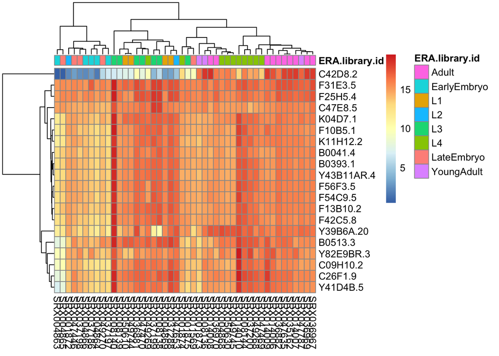

```r
annot_df2<-data.frame(ERA.library.id=colData(expr_se2)$ERA.library.id,
                      row.names=row.names(colData(expr_se2)))

pheatmap(assay(ntd2) [Top20_2,], annotation_col = annot_df2) #heat map with annotation
```

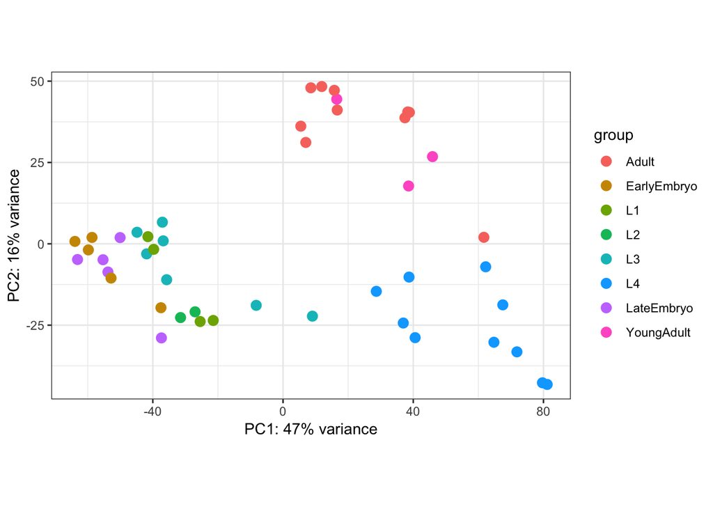

```r
plotPCA(vsd2, intgroup="ERA.library.id") + theme_bw()
```

#### *Figure 3.* **8 Stages Heat Map** and *Figure 4.* **8 Stages PCA Plot**

The Figure 3 heat map shows us regions of higher and lower gene expression similar to Figure 1’s heat map. The early embryo, late embryo, and the larval L1, L2 & L3 stages show a very low expression (regions of blue) of the vitellogenin-2 protein gene (C42D8.2) which is a precursor protein of egg yolk. However, this gene is highly expressed in the L4 larval stage, young adult and adult stages. The Figure 4 PCA plot shows clusters of the stages. Here we see that the Adult, Young adult and L4 larval stage genes are clustered farther from the rest of the stages, showing a strong differentiation in the top20 genes. The Early and late embryo along with the L1, L2 and L3 larval stages are tightly clustered together, away from the L4 and adults/young adults. The pc1 explains 47% of variance and pc2 explains 16% variation in expression.

# PART 2:Phylogenic Analysis

## 1. Load packages

```r
suppressMessages(library(BiocManager))
suppressMessages(library(genbankr))
suppressMessages(library(rentrez))
suppressMessages(library(annotate))
suppressMessages(library(ape))
suppressMessages(library(ggplot2))
suppressMessages(library(reshape2))
suppressMessages(library(ggtree))
```

## 2. Load Fasta file

```r
install.packages("readr",repos = "http://cran.us.r-project.org")
library(readr)
mystring <- read_file("data/sequence.fasta.txt")
```

The sequence of the gene Vitellogenin-2 was retrived from NCBI. The accession code is NM_001129645 and the gene is 4677 base pairs long.

## 3. Remove header and other characters

```r
Header1<-gsub(".*X","", mystring)
seq<-gsub("[\n]+","", Header1)
```

## 4. Run BLAST search and re-format data

```r
#make new dataframe with 2 new columns that have the accession ID and HIT sequence
UnknownBLAST<-blastSequences(paste(seq), as="data.frame",
                             hitListSize = 40, timeout = 180, database="nr",program="blastn") #use blastn for nucleotides
```

```
## estimated response time 11 seconds
```

```
## elapsed time 11 seconds
```

```r
HitsDF<-data.frame(ID=UnknownBLAST$Hit_accession,#only take sequences that align
                   Seq=UnknownBLAST$Hsp_hseq, stringsAsFactors = FALSE)

HitsDNA<-sapply(HitsDF$Seq, strsplit, split="") #seperates sequences into individual base pairs (new column for each basepair)

names(HitsDNA)<-paste(1:nrow(HitsDF), HitsDF$ID, sep="_") #Add accession ID to remove repeats

HitsDNA<-as.DNAbin(HitsDNA) #final format before alignment
```

## 5. Gap lengths

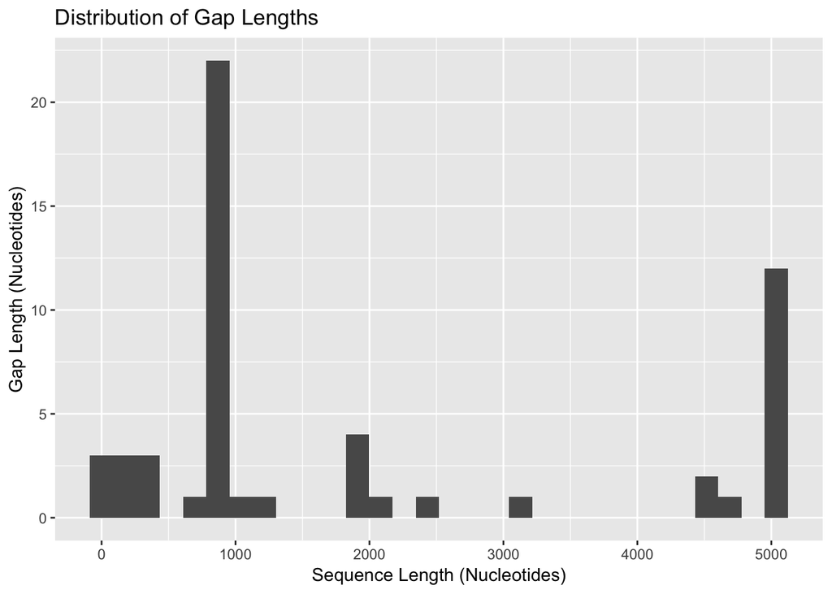

```r
SeqLen<-as.numeric(lapply(HitsDNA, length)) #check to see relative distribution of gap lengths (may need to remove some for better alignment)

qplot(SeqLen, xlab="Sequence Length (Nucleotides)", ylab="Gap Length (Nucleotides)", main="Distribution of Gap Lengths")
```

## 6. Alignment of HIT DNA sequences from BLAST search

```
##
## Number of sequences: 56
## Number of sites: 5149
##
## Some gap lengths are not multiple of 3: 1 2 4 7 10 14 22 23 25 26 29 34 47 49 50 52 56 59 68 73 74 85 91 121 236 244 421 605 625 829 1480 1595 1678 1696 1697 1703 1831 1853 1856 2021 2312 2620 2621 2722 2755 2828 3232 4436
##
## Frequencies of gap lengths:
##    1    2    3    4    6    7    9   10   12   14   15   18   21   22   23
##   67   30  149    8   16    1    3    3    3    1    1    2    2    1    2
##   24   25   26   27   29   30   34   47   48   49   50   52   56   59   68
##    2    1    1    7    1    2    1    1    5   22    2    3    2    1    1
##   73   74   85   91   93   99  102  121  144  156  192  198  231  236  244
##    2    3    7    1    1    1    2    1    2    1    1    1    2    1    1
##  315  348  378  421  456  605  612  625  829 1179 1281 1380 1480 1595 1602
##    1    1    1    1    1    3    1    1    1    1    1    1    1    1    1
## 1626 1678 1689 1696 1697 1703 1831 1851 1853 1856 1977 2021 2082 2312 2391
##    1    1   18    1    1    1    1    1    1    1    1    1    1    1    1
## 2610 2620 2621 2700 2722 2739 2755 2826 2828 3093 3165 3225 3232 4436
##    1   20    1    1    2    1    1    3    1    1    1    1    1    1
##    => length of gaps on the left border of the alignment: 2722 2826 2828 2021 1595 3165 4436 2610 1602 3093 2700 2391 1380 2620 2621
##    => length of gaps on the right border of the alignment: 3232 3225 2755 2739 2312 1977 1856 1853 1851 1831 1703 1697 1689 1689 1689 1689 1689 1689 1689 1689 1689 1689 1689 1689 1689 1689 1689 1689 1689 1689 1480 829 612 605 605 605 421 4 4 2 2 2 2 2 2 2
##
## Number of unique contiguous base segments defined by gaps: 152
## Number of segment lengths not multiple of 3: 105
##     => on the left border of the alignement: 5
##     => on the right border                 : 1
##     => positions of these segments inside the alignment: 530..900 952..1259 1261..1270 1273..1396 1403..2073 2077..2338 2340..2904 2908..3272 3358..3511 4389..4878 4881..4963 485..891 907..1259 1262..2073 2077..2099 2103..2353 3515..4544 485..924 935..1259 2723..2733 2833..2839 2861..2874 3106..3…
##
## Number of segregating sites (including gaps): 5149
## Number of sites with at least one substitution: 3144
## Number of sites with 1, 2, 3 or 4 observed bases:
##    1    2    3    4
##    0 2041  930  173
```

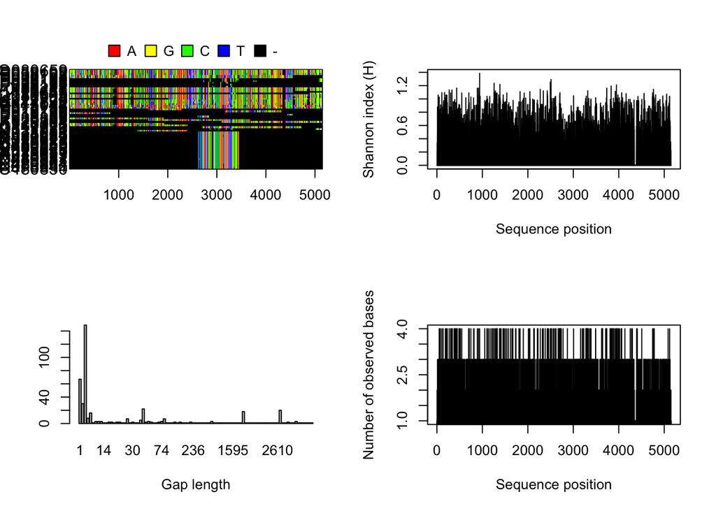

```r
AlignDNA<-muscle(HitsDNA, quiet=F) #search MUSCLE aligner

checkAlignment(AlignDNA) #show alignment plots
```

#### *Figure 6.* **Alignment Plots**

Therefore, this series of diagnostics show us a moderate alignment of our 56 HIT sequences from the nucleotide BLAST search of our unknown DNA sequence.

## 7. Adding Species names

```r
Subset<-read.GenBank(UnknownBLAST$Hit_accession)
HITseqNames<-attr(Subset, "species")
print(HITseqNames[1])
```

```
## [1] "Caenorhabditis_elegans"
```

## 8. Convert alignment to a Distance Matrix and Visualize

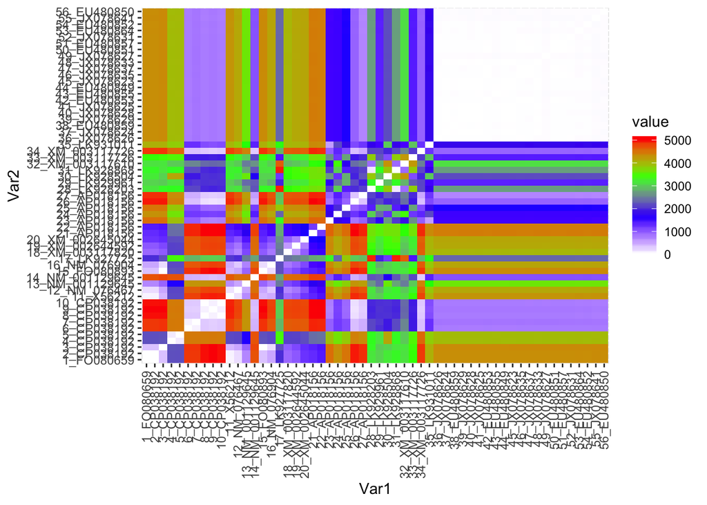

```r
DnaDM1<- dist.gene(AlignDNA,method="pairwise")
DnaDMmat1<-as.matrix(DnaDM1)
Dat1<-melt(DnaDMmat1)

ggplot(data=Dat1, aes(x=Var1, y=Var2, fill=value)) +
  geom_tile() +scale_fill_gradientn(colours=c("white", "blue", "green", "red"))+
  theme(axis.text.x=element_text(angle=90,hjust=1,vjust=0.5))
```

#### *Figure 7.* **Dixtance matrix plot**

The distance matrix plot of the HIT sequences. Almost a half of the sequences are identical. These identical sequenes are all part of *Caenorhabditis remanei* strain VX0007 VIT-2 (vit-2) gene. The original sequence of interest is 13_NM_001129645. Some of the similar sequences includes FO080659,X56212 and NM_076467. These sequences are all either directly related to the vit-2 gene or it’s a sequence from a strain from the X chromosom, all three of them found in *C.elegans* .

## 9. Tree building using the Neighbour-Joining approach

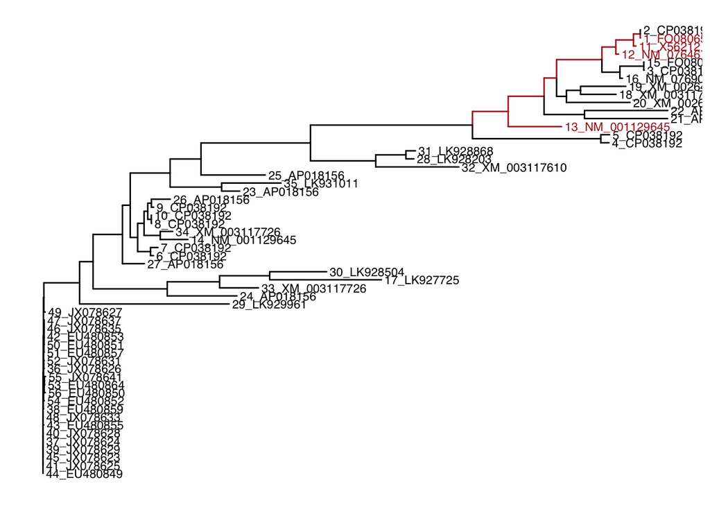

```r
treenj<-nj(DnaDM1)
os<-c("13_NM_001129645","11_X56212","12_NM_076467","1_FO080659")
njt<-ggtree(treenj)
groupOTU(njt,os)+aes(color=group) + geom_tiplab(size=3) + scale_color_manual(values=c("black", "firebrick"))
```

#### *Figure 8.* **Neighbour joining tree**

The phylogenetic tree of HIT sequences. Just as illustrated from the distance matrix plot, the sequences from *Caenorhabditis remanei* VIT-2 gene cluster together whereas the *C. elegans* sequences are less clustered and have more sequence varition. The original sequence (13) and the three most similar sequences (1, 11, 12) are in red.

## 10. Tree building using the Minimum Evolution approach

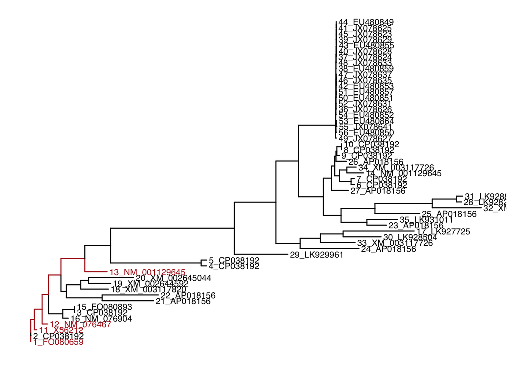

```r
treeme<-fastme.bal(DnaDM1)
met<-ggtree(treeme)
groupOTU(met,os)+aes(color=group) + geom_tiplab(size=3) + scale_color_manual(values=c("black", "firebrick"))
```

#### *Figure 9.* **Minimum evolution tree**

The phylogenetic tree of HIT sequences using minimum evolution method. The tree looks very different from that generated using a neighbour joining method. Despite the formatting differences, general patterns of clustering are consistent between the two trees. As above, the original sequence (13) and three most similar sequences (1, 11, 12) are in red.

# Conclusion

This analysis addressed the following questions: A) What genes are differentially expressed at different developmental stages in *C. elegans*; and B) Based on the most differentiated gene across the developmental stages, is there homology in that gene amongst different species?

Multiple alignment showed high variability between *C. elegans* strains in the first half of the sequence hits (Figure 6.1), suggesting there is not a conserved domain. However, the last half of squence hits showed a small, highly conserved domain but no common basepairs surrounding it. A heat map shows similar results with the first sequences showing lots of variation and the last sequences being highly conserved (Figure 7).

A phylogenetic tree of these BLAST hits shows clustering of the sequences from *Caenorhabditis remanei* VIT-2 gene and more evolutionary distance between sequences from *C. elegans* (Figure 8). This result was mostly consistent between both the neighbour joining and minimum evolution methods of tree creation (Figure 9). Although there is some differences between the two, they show almost identical orders of relation with different branch lengths. The strains of *C. remanei* with highly conserved sequences are monophyletic with little evolutionary distance between them whereas the *C. elegans* strains are more distant.

In conclusion, the genes analyzed in *C. elegans* show expression patterns consistent with their stage of development. These genes are not highly conserved among *C. elegans* strains. Therefore, they are likely not crucial genes under evolutionary constraint for strains of *C. elegans*, unlike the conserved domain in *C. remanei*.